```r
library(tidyverse)
```

# Lecture 06

In this notebook, we cover the first part of [R4DS §7](http://r4ds.had.co.nz/exploratory-data-analysis.html):

- Visualizing distributions
- Typical and Unusual Values
- Missing Values

## Visualizing distributions

Recall that a **categorical** variable is one that can only take one of a (small) finite number of values. For example, in the `diamonds` data set, `color` is a categorical variable.

```r
print(diamonds)
```

```
# A tibble: 53,940 x 10
   carat cut       color clarity depth table price     x     y     z
   <dbl> <ord>     <ord> <ord>   <dbl> <dbl> <int> <dbl> <dbl> <dbl>
 1 0.230 Ideal     E     SI2      61.5  55.0   326  3.95  3.98  2.43
 2 0.210 Premium   E     SI1      59.8  61.0   326  3.89  3.84  2.31
 3 0.230 Good      E     VS1      56.9  65.0   327  4.05  4.07  2.31
 4 0.290 Premium   I     VS2      62.4  58.0   334  4.20  4.23  2.63
 5 0.310 Good      J     SI2      63.3  58.0   335  4.34  4.35  2.75
 6 0.240 Very Good J     VVS2     62.8  57.0   336  3.94  3.96  2.48
 7 0.240 Very Good I     VVS1     62.3  57.0   336  3.95  3.98  2.47
 8 0.260 Very Good H     SI1      61.9  55.0   337  4.07  4.11  2.53
 9 0.220 Fair      E     VS2      65.1  61.0   337  3.87  3.78  2.49
10 0.230 Very Good H     VS1      59.4  61.0   338  4.00  4.05  2.39
# ... with 53,930 more rows
```

Say we are interested in the distribution of the `color`. We can plot a bar chart to visualize this:

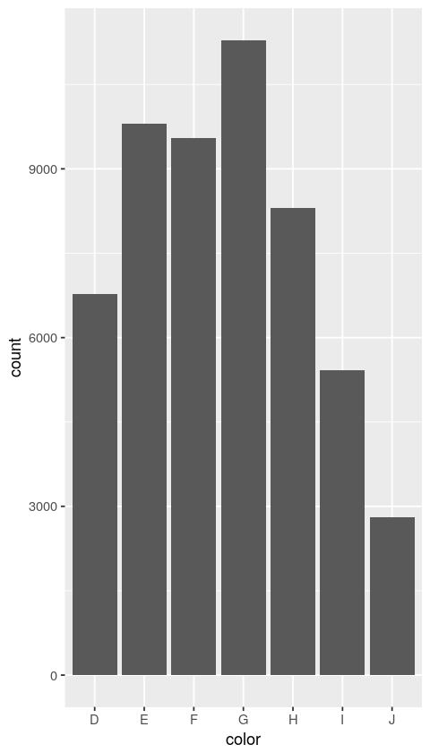

```r
ggplot(data = diamonds) +
    geom_bar(mapping = aes(x = color))
```

Here ggplot has done some work for us: it has grouped the data by color, summarized it, and plotted a bar graph of the result. Let's reproduce this ourselves using the knowledge we have gained from §5:

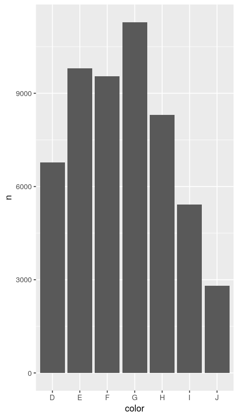

```r
count(diamonds, color) %>% ggplot(aes(x=color, y=n)) + geom_col()
```

A **continuous** variable can take one of an infinite number of ordered values. Let us look at the **dep_delay** variables from the `flights` data set. Note that we are about to use a new ggplot geometry, namely **geom_histogram**. It can be used to visualize the distribution of a continuous variable.

```
Warning message:
“Removed 8255 rows containing non-finite values (stat_bin).”
```

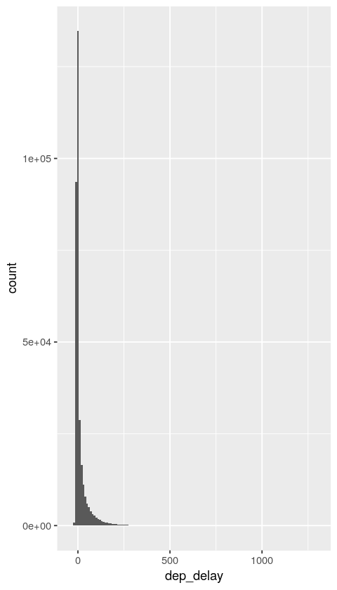

```r
library(nycflights13)
    ggplot(data = flights) +
        geom_histogram(mapping = aes(x = dep_delay), binwidth = 10)
```

Here ggplot is warning us that 8,255 rows got dropped. We should verify that we know exactly why these rows could not be plotted:

```r
flights %>% filter(is.na(dep_delay)) %>% count()
```

```
  n
1 8255
```

Now let us work with non-missing values only.

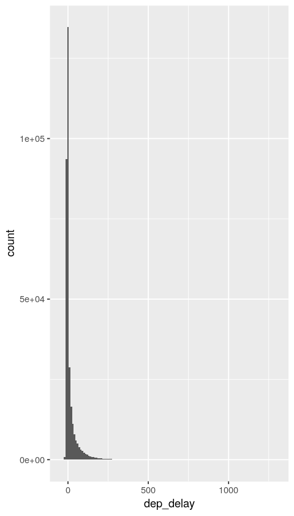

```r
flights_nona = filter(flights, !is.na(dep_delay))
ggplot(flights_nona) +
    geom_histogram(mapping = aes(x = dep_delay), binwidth = 10)
```

Let us zoom into the left part of the plot. Let us only look at flights with departure delays of less than an hour.

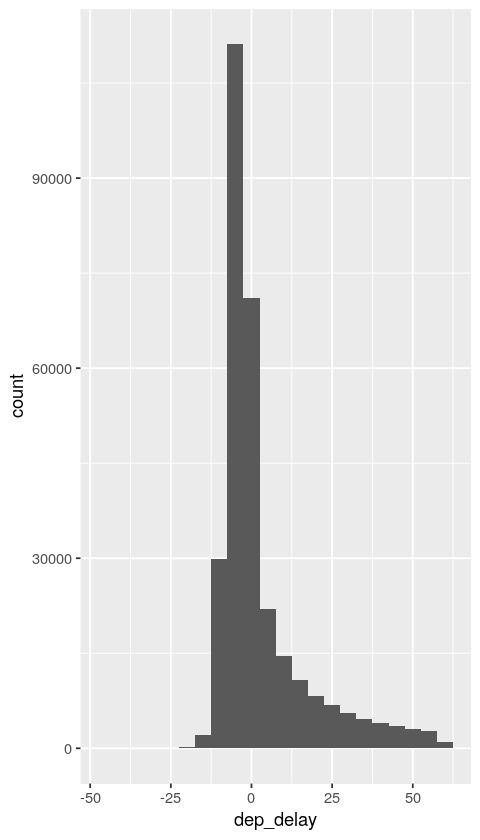

```r
flights_nona %>%
    filter(dep_delay < 60) %>%
    ggplot() +
        geom_histogram(mapping = aes(x = dep_delay), binwidth = 5) # we choose a smaller bin width now
```

We will again reproduce this plot by hand using the tools we developed earlier. The `cut_width(v, k)` function can be used to count how many observations in `v` fall into buckets of width `k`. In the preceding plot we chose a `binwidth=5` so that will be our value of `k`.

```
# A tibble: 21 x 2
   cw                 n
   <fctr>         <int>
 1 [-47.5,-42.5]      1
 2 (-37.5,-32.5]      1
 3 (-32.5,-27.5]      2
 4 (-27.5,-22.5]     14
 5 (-22.5,-17.5]    160
 6 (-17.5,-12.5]   2079
 7 (-12.5,-7.5]   29878
 8 (-7.5,-2.5]   111111
 9 (-2.5,2.5]     71126
10 (2.5,7.5]      22013
# ... with 11 more rows
```

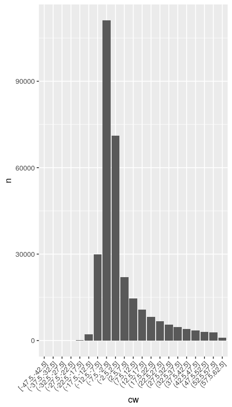

```r
flights_nona %>% filter(dep_delay < 60) %>%
    count(cw=cut_width(dep_delay, 5)) %>% print %>% ggplot(aes(x=cw, y=n)) + geom_col() +
    theme(axis.text.x = element_text(angle = 45, hjust = 1))
```

The appearance of a histogram does depend on your choice of the bin width. It is a good idea to try several values to see if different choices reveal different patterns.

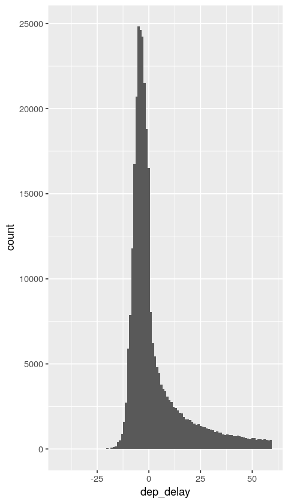

```r
flights_nona %>%
    filter(dep_delay < 60) %>%
    ggplot() +
        geom_histogram(mapping = aes(x = dep_delay), binwidth = 1) # we choose an even smaller bin width now
```

Let us bring in the categorical variable **carrier** and map the color aesthetic to it.

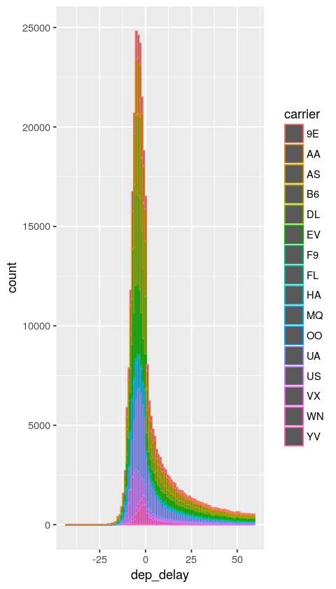

```r
flights_nona %>%
    filter(dep_delay < 60) %>%
        ggplot() +
            geom_histogram(mapping = aes(x = dep_delay, color = carrier), binwidth = 1)
```

The legend is a bit crowded. Let us see who the major carriers are by number of flights.

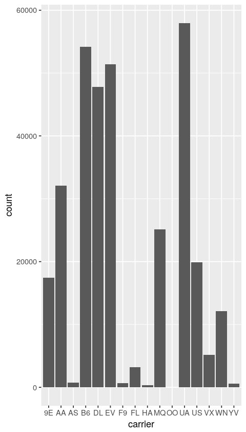

```r
flights_nona %>% ggplot() +
        geom_bar(mapping = aes(x = carrier))
```

Visually, we see that the top 5 carriers by flight count are AA, B6, DL, EV and UA. But let us compute this using pipes.

```r
library(magrittr)
(top5 <- flights_nona %>%
    group_by(carrier) %>%
    summarize(count = n()) %>%
    top_n(5, count)
    %$% carrier) # new syntax -- %$% extracts a column as an R vector
```

```
[1] "AA" "B6" "DL" "EV" "UA"
```

Now we can additionally filter out rows that do not belong to the top 5 carriers.

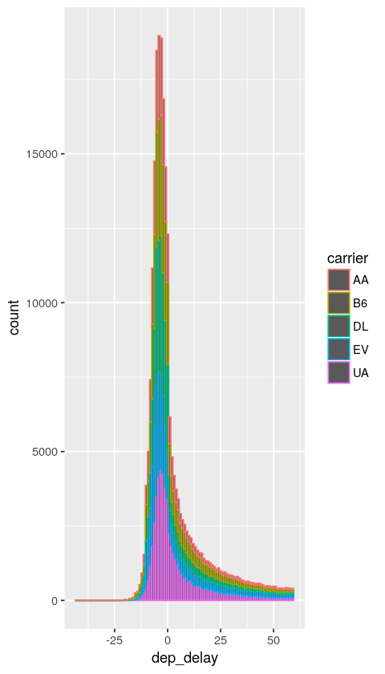

```r
flights_nona %>%
    filter(dep_delay < 60, carrier %in% top5) %>%
    ggplot() +
        geom_histogram(mapping = aes(x = dep_delay, color = carrier), binwidth = 1)
```

This is better but still not very clean. Let us use a new geometry **freqpoly** which is like histogram but shows lines. Overlapping lines are easier to see than overlapping bars.

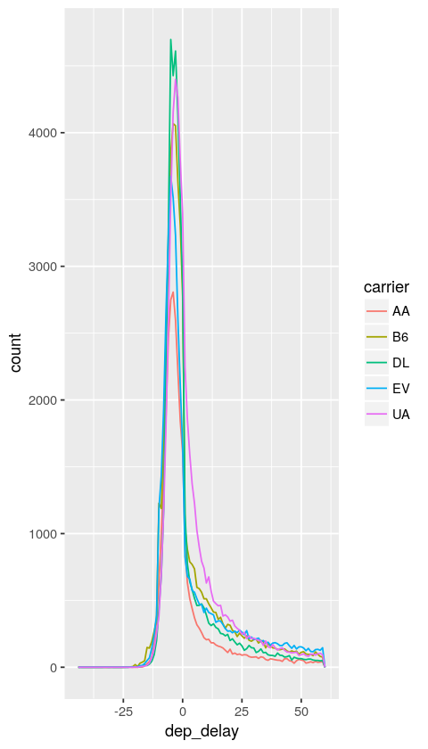

```r
flights_nona %>%
    filter(dep_delay < 60, carrier %in% top5) %>%
    ggplot() +
        geom_freqpoly(mapping = aes(x = dep_delay, color = carrier), binwidth = 1)
```

## Typical and Unusual Values

In EDA, it is a good idea to try and get a sense of what constitutes a "typical" value in your data. Let us look at the distribution of the **$x$** variable. (Recall that $x$ in this dataset refers to the length of the diamond measured in mm.)

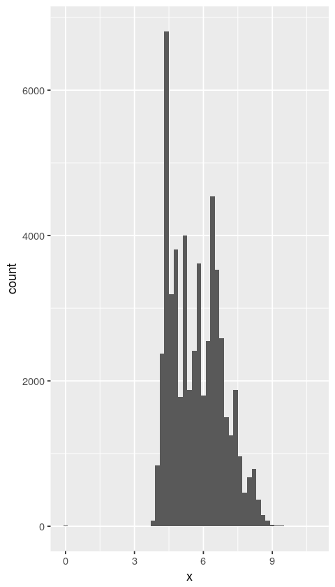

```r
ggplot(data = diamonds) +
    geom_histogram(mapping = aes(x = x), binwidth = 0.2)
```

Typical values of $x$ in these data range from about 4 to 9. It is difficult to see, but there are some values close to 0 as well as values larger than 10 that are very uncommon. We can confirm this using the filtering commands that we learned last week:

```r
filter(diamonds, x < 1 | x > 10) %>% arrange(x)
```

```
   carat cut       color clarity depth table price x     y     z
1  1.07  Ideal     F     SI2     61.6  56     4954  0.00  6.62 0.00
2  1.00  Very Good H     VS2     63.3  53     5139  0.00  0.00 0.00
3  1.14  Fair      G     VS1     57.5  67     6381  0.00  0.00 0.00
4  1.56  Ideal     G     VS2     62.2  54    12800  0.00  0.00 0.00
5  1.20  Premium   D     VVS1    62.1  59    15686  0.00  0.00 0.00
6  2.25  Premium   H     SI2     62.8  59    18034  0.00  0.00 0.00
7  0.71  Good      F     SI2     64.1  60     2130  0.00  0.00 0.00
8  0.71  Good      F     SI2     64.1  60     2130  0.00  0.00 0.00
9  4.00  Very Good I     I1      63.3  58    15984 10.01  9.94 6.31
10 4.01  Premium   J     I1      62.5  62    15223 10.02  9.94 6.24
 [ reached getOption("max.print") -- omitted 3 rows ]
```

An important thing to note from these data is that several of the diamonds have $x=0$, which is impossible. So these represent some sort of error in the data, and we can safely drop them. The very large diamonds, on the other hand, seem to be genuinely large and valuable. We would want to think twice about dropping them in later analysis.

A good way to get a sense of typical values is by looking at percentiles. The $p$th percentile of a column is the number $x$ for which $p$% of the values are less than or equal to $x$. The best known example is the *median*: half the values are below the median.

```r
(q = quantile(diamonds$x, probs=c(.01, .5, .99)))
```

```
  1%  50%  99%
4.02 5.70 8.36
```

This tells us that 98% of the $x$-values or between 4.02 and 8.36. Let us redo the visualization with extreme values filtered out.

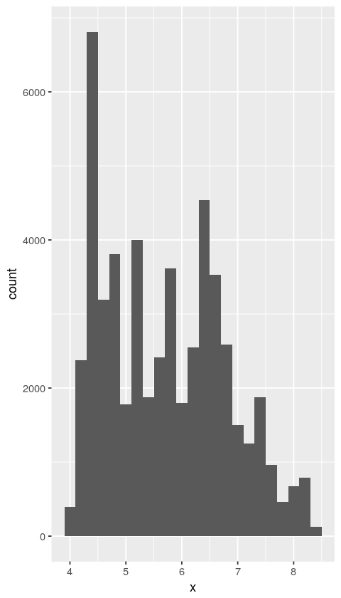

```r
filter(diamonds, x >= q[1], x <= q[3]) %>%
    ggplot() +
        geom_histogram(mapping = aes(x = x), binwidth = 0.2)
```

Let us now look at the distribution of the **$y$** variable. $y$ measures width in mm.

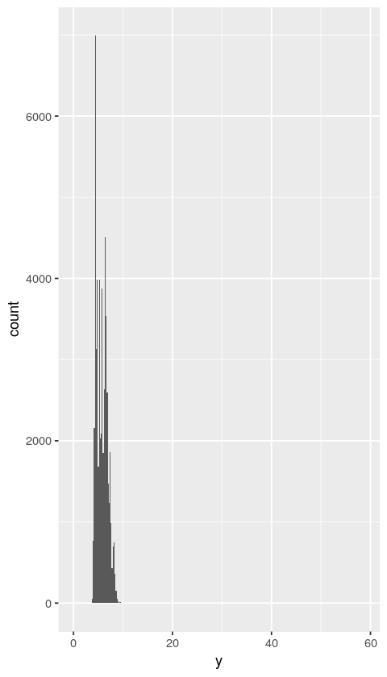

```r
ggplot(data = diamonds) +
    geom_histogram(mapping = aes(x = y), binwidth = 0.2)
```

Repeating the analysis for $y$, we see a similar pattern for the outlying values:

```r
filter(diamonds, y < 1 | y > 10) %>% arrange(y)
```

```
   carat cut       color clarity depth table price x     y     z
1  1.00  Very Good H     VS2     63.3  53     5139  0.00  0.00 0.00
2  1.14  Fair      G     VS1     57.5  67     6381  0.00  0.00 0.00
3  1.56  Ideal     G     VS2     62.2  54    12800  0.00  0.00 0.00
4  1.20  Premium   D     VVS1    62.1  59    15686  0.00  0.00 0.00
5  2.25  Premium   H     SI2     62.8  59    18034  0.00  0.00 0.00
6  0.71  Good      F     SI2     64.1  60     2130  0.00  0.00 0.00
7  0.71  Good      F     SI2     64.1  60     2130  0.00  0.00 0.00
8  4.01  Premium   I     I1      61.0  61    15223 10.14 10.10 6.17
9  4.50  Fair      J     I1      65.8  58    18531 10.23 10.16 6.72
10 5.01  Fair      J     I1      65.5  59    18018 10.74 10.54 6.98
 [ reached getOption("max.print") -- omitted 2 rows ]
```

The quantiles for $y$ are:

```r
(qy = quantile(diamonds$y, probs=c(.01, .5, .99)))
```

```
  1%  50%  99%
4.04 5.71 8.34
```

Let us redo the distribution of **y** with unusual values filtered out. Note here the use of the `between()` filtering predicate.

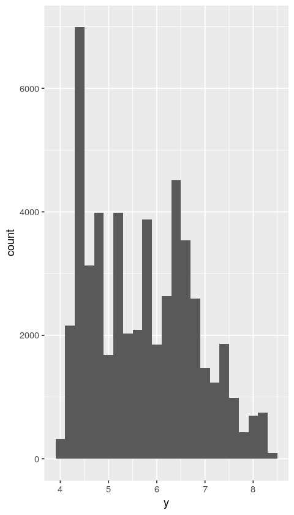

```r
filter(diamonds, between(y, qy[1], qy[3])) %>%
    ggplot() +
        geom_histogram(mapping = aes(x = y), binwidth = 0.2)
```

Finally, let us examine the **z** variable.

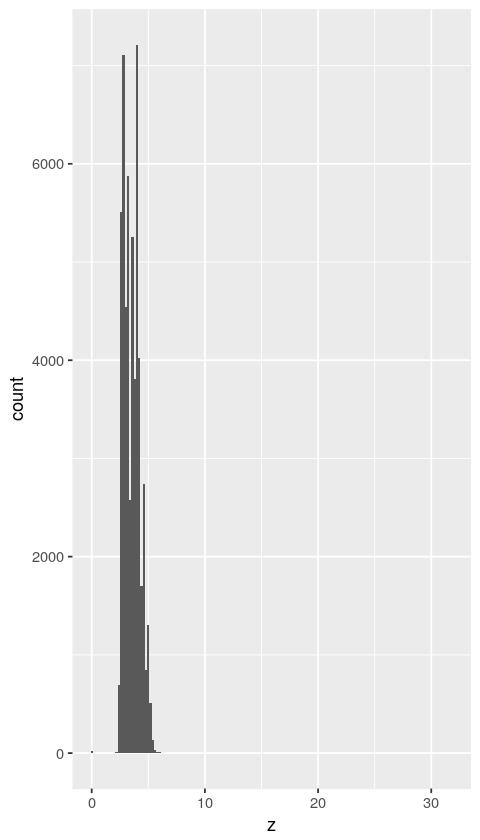

```r
ggplot(data = diamonds) +
    geom_histogram(mapping = aes(x = z), binwidth = 0.2)
```

As before, we focus on the unusual values at the two extremes.

```r
filter(diamonds, z < 1 | z > 10) %>% arrange(z)
```

```
   carat cut       color clarity depth table price x    y    z
1  1.00  Premium   G     SI2     59.1  59.0   3142 6.55 6.48  0.0
2  1.01  Premium   H     I1      58.1  59.0   3167 6.66 6.60  0.0
3  1.10  Premium   G     SI2     63.0  59.0   3696 6.50 6.47  0.0
4  1.01  Premium   F     SI2     59.2  58.0   3837 6.50 6.47  0.0
5  1.50  Good      G     I1      64.0  61.0   4731 7.15 7.04  0.0
6  1.07  Ideal     F     SI2     61.6  56.0   4954 0.00 6.62  0.0
7  1.00  Very Good H     VS2     63.3  53.0   5139 0.00 0.00  0.0
8  1.15  Ideal     G     VS2     59.2  56.0   5564 6.88 6.83  0.0
9  1.14  Fair      G     VS1     57.5  67.0   6381 0.00 0.00  0.0
10 2.18  Premium   H     SI2     59.4  61.0  12631 8.49 8.45  0.0
 [ reached getOption("max.print") -- omitted 11 rows ]
```

Now we redo the **z** distribution with unusual values filtered out.

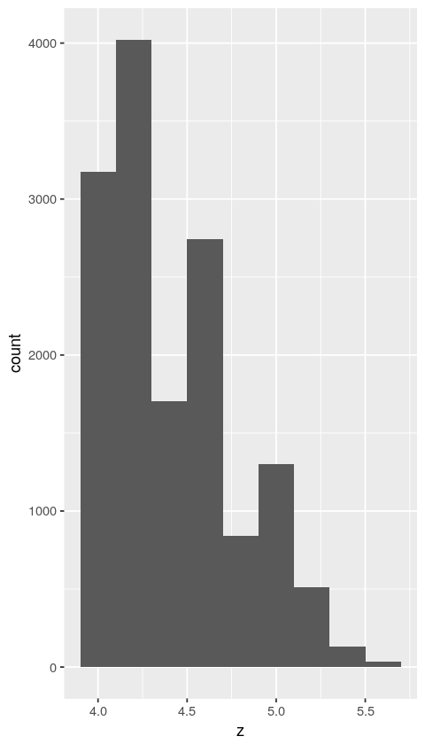

```r
qz = quantile(diamonds$z, probs = c(.01,.99))
filter(diamonds, z >= q[1], z <= q[2]) %>%
    ggplot() +
        geom_histogram(mapping = aes(x = z), binwidth = 0.2)
```

We now want to look at the **price** distribution. Let us first get a sense of the overall spread of price in these data:

```r
summarize(diamonds, max = max(price), min = min(price))
```

```
  max   min
1 18823 326
```

The price ranges from 18,823 USD down to 326 USD. Let us initially choose a bin width of 1000 USD, which will give us about 20 bins.

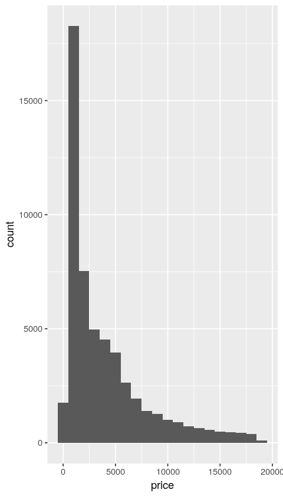

```r
ggplot(data = diamonds) +
    geom_histogram(mapping = aes(x = price), binwidth = 1000)
```

This makes sense. The distribution peaks well below 2,500 USD and decays slowly towards very high prices.

Let us change to a bin width of 100 to see a surprise!

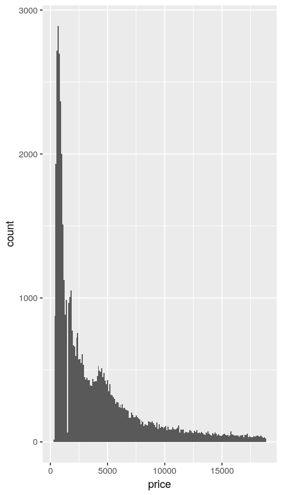

```r
ggplot(data = diamonds) +
    geom_histogram(mapping = aes(x = price), binwidth = 100)
```

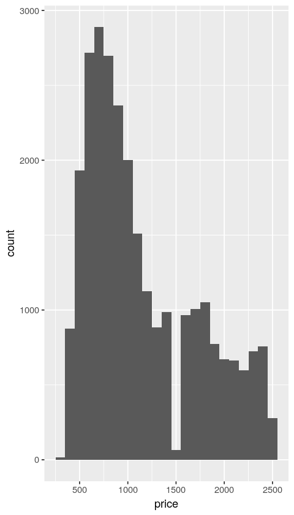

```r
filter(diamonds, price <= 2500) %>%
    ggplot() +
    geom_histogram(mapping = aes(x = price), binwidth = 100)
```

Hmmm... So few diamonds near the price of 1500 USD. What's going on? Let us decrease the bin width to 50 USD.

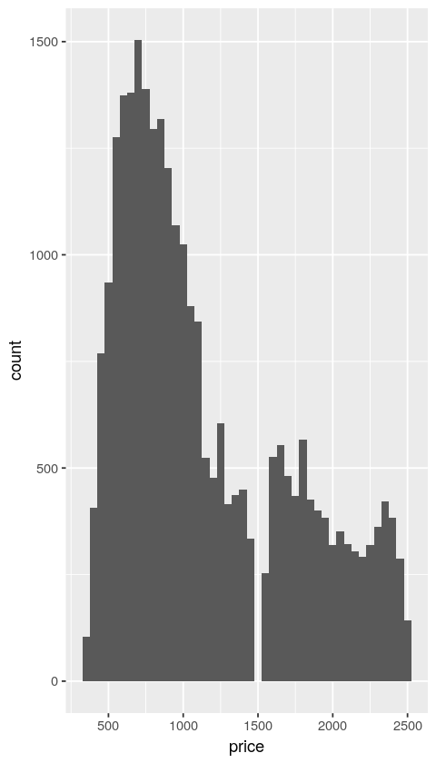

```r
filter(diamonds, price <= 2500) %>%
    ggplot() +
        geom_histogram(mapping = aes(x = price), binwidth = 50)
```

It really appears that the 1,500 USD price tag is being avoided!!!

```r
arrange(diamonds, price) %>% filter(price > 1452) %>% print
```

```
# A tibble: 33,938 x 10
   carat cut       color clarity depth table price     x     y     z
   <dbl> <ord>     <ord> <ord>   <dbl> <dbl> <int> <dbl> <dbl> <dbl>
 1 0.580 Very Good E     SI1      59.6  57.0  1453  5.41  5.42  3.23
 2 0.460 Ideal     G     VVS1     60.7  57.0  1453  4.98  5.03  3.04
 3 0.540 Ideal     H     VS2      61.6  55.0  1453  5.23  5.25  3.23
 4 0.540 Ideal     H     VS2      61.5  55.0  1453  5.25  5.28  3.24
 5 0.540 Ideal     I     VS1      63.1  55.0  1453  5.18  5.22  3.27
 6 0.500 Very Good D     SI1      61.6  56.0  1454  5.09  5.11  3.14
 7 0.520 Ideal     I     VVS1     60.1  56.0  1454  5.24  5.27  3.16
 8 0.540 Ideal     H     VS1      61.2  55.0  1454  5.25  5.31  3.23
 9 0.510 Premium   G     VS2      61.2  60.0  1546  5.17  5.12  3.15
10 0.510 Ideal     G     VS2      62.9  54.0  1546  5.12  5.08  3.21
# ... with 33,928 more rows
```

Is this by chance or is there something else going on? Let's look at the differences in price between each distinct value of price:

```
  price dprice
1  1546 92
2 15646 19
3 16169 18
4 17975 18
5 17634 17
6 14014 16
```

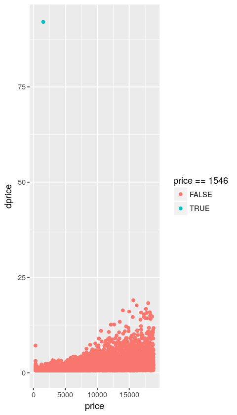

```r
prices = arrange(diamonds, price) %>% distinct(price) %>% .[['price']]
df = data.frame(price=prices, dprice=c(NA, diff(prices)))
head(arrange(df, desc(dprice)))
ggplot(df) + geom_jitter(aes(x=price, y=dprice, color=price==1546))
```

Now we examine the **carat** distribution.

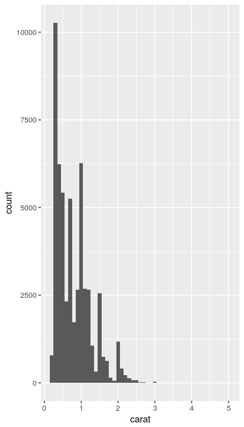

```r
ggplot(data = diamonds) +
    geom_histogram(mapping = aes(x = carat), binwidth = 0.1)
```

What's going on near 3? Let us investigate...

```r
filter(diamonds, carat > 3) %>% arrange(carat) %>% print
```

```
# A tibble: 32 x 10
   carat cut     color clarity depth table price     x     y     z
   <dbl> <ord>   <ord> <ord>   <dbl> <dbl> <int> <dbl> <dbl> <dbl>
 1  3.01 Premium I     I1       62.7  58.0  8040  9.10  8.97  5.67
 2  3.01 Premium F     I1       62.2  56.0  9925  9.24  9.13  5.73
 3  3.01 Fair    H     I1       56.1  62.0 10761  9.54  9.38  5.31
 4  3.01 Premium G     SI2      59.8  58.0 14220  9.44  9.37  5.62
 5  3.01 Ideal   J     SI2      61.7  58.0 16037  9.25  9.20  5.69
 6  3.01 Ideal   J     I1       65.4  60.0 16538  8.99  8.93  5.86
 7  3.01 Premium I     SI2      60.2  59.0 18242  9.36  9.31  5.62
 8  3.01 Fair    I     SI2      65.8  56.0 18242  8.99  8.94  5.90
 9  3.01 Fair    I     SI2      65.8  56.0 18242  8.99  8.94  5.90
10  3.01 Good    I     SI2      63.9  60.0 18242  9.06  9.01  5.77
# ... with 22 more rows
```

Okay, now let us zoom into the **carat** range around 1.

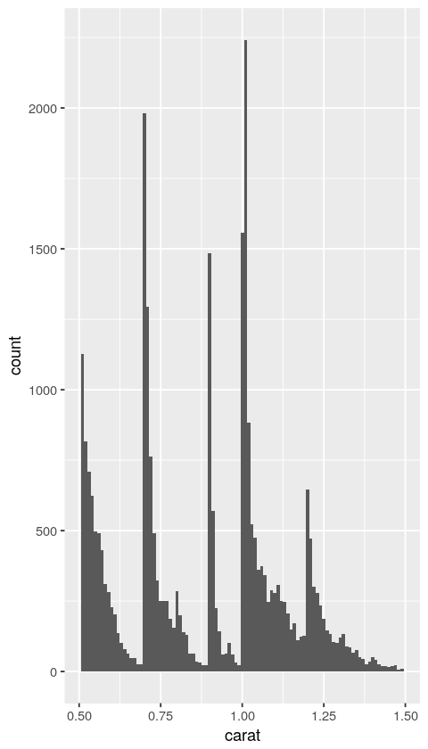

```r
filter(diamonds, carat > 0.5, carat < 1.5) %>% ggplot() + geom_histogram(mapping = aes(x = carat),
    binwidth = 0.01)
```

What might explain the strange histogram above? Tendency to round the **carat** values? It seems like certain values are particularly likely to be rounded. Let's refine the plot using the `breaks=` option to investigate further:

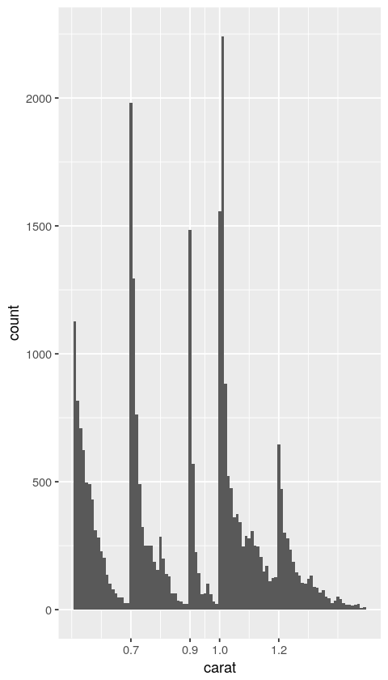

```r
filter(diamonds, carat > 0.5, carat < 1.5) %>% ggplot() + geom_histogram(mapping = aes(x = carat),
    binwidth = 0.01) + scale_x_continuous(breaks=c(.7,.9,1.,1.2))
```

Sure enough, there are certain values of carat that people seem to particularly desire.

## Missing Values

Remember those zero values for **x, y, z** variables? They are almost certainly the result of data entry errors.

```r
filter(diamonds, near(x,0) | near(y,0) | near(z, 0)) %>% print
```

```
# A tibble: 20 x 10
   carat cut       color clarity depth table price     x     y     z
   <dbl> <ord>     <ord> <ord>   <dbl> <dbl> <int> <dbl> <dbl> <dbl>
 1 1.00  Premium   G     SI2      59.1  59.0  3142  6.55  6.48     0
 2 1.01  Premium   H     I1       58.1  59.0  3167  6.66  6.60     0
 3 1.10  Premium   G     SI2      63.0  59.0  3696  6.50  6.47     0
 4 1.01  Premium   F     SI2      59.2  58.0  3837  6.50  6.47     0
 5 1.50  Good      G     I1       64.0  61.0  4731  7.15  7.04     0
 6 1.07  Ideal     F     SI2      61.6  56.0  4954  0     6.62     0
 7 1.00  Very Good H     VS2      63.3  53.0  5139  0     0        0
 8 1.15  Ideal     G     VS2      59.2  56.0  5564  6.88  6.83     0
 9 1.14  Fair      G     VS1      57.5  67.0  6381  0     0        0
10 2.18  Premium   H     SI2      59.4  61.0 12631  8.49  8.45     0
11 1.56  Ideal     G     VS2      62.2  54.0 12800  0     0        0
12 2.25  Premium   I     SI1      61.3  58.0 15397  8.52  8.42     0
13 1.20  Premium   D     VVS1     62.1  59.0 15686  0     0        0
14 2.20  Premium   H     SI1      61.2  59.0 17265  8.42  8.37     0
15 2.25  Premium   H     SI2      62.8  59.0 18034  0     0        0
16 2.02  Premium   H     VS2      62.7  53.0 18207  8.02  7.95     0
17 2.80  Good      G     SI2      63.8  58.0 18788  8.90  8.85     0
18 0.710 Good      F     SI2      64.1  60.0  2130  0     0        0
19 0.710 Good      F     SI2      64.1  60.0  2130  0     0        0
20 1.12  Premium   G     I1       60.4  59.0  2383  6.71  6.67     0
```

Let us create a new data set with the unusual values replaces with NA. That is, we are explicitly marking them as **missing values**.

We will use a new function below: `ifelse()`.

```r
diamonds_new <- diamonds %>%
                    mutate(x = ifelse(x < 3 | x > 10, NA, x)) %>%
                    mutate(y = ifelse(y < 3 | y > 20, NA, y)) %>%
                    mutate(z = ifelse(z < 3 | z > 10, NA, z))
```

Note that we are also treating extreme values as missing in this example. This is fine, so long as you are confident that the extreme values are due to some sort of error or anomaly.

If they *actually* represent valid data points, then you need to do additional analysis to understand what mechanism generated such values.

It is very important to mark missing data as such in your analysis. Otherwise, your computations can be misleading. For example, consider the min $x$ value in `diamonds` compared to `diamonds_new`:

```r
diamonds %>% summarize(min_x=min(x))
diamonds_new %>% summarize(min_x=min(x))
diamonds_new %>% summarize(min_x=min(x, na.rm=T))
```

```
  min_x
1 0
```

```
  min_x
1 NA
```

```
  min_x
1 3.73
```

We get a completely different answer, of course. This example is contrived but you can imagine that if a large number of missing values were coded as `0`, as in this example, things like means and regression fits could be substantially altered depending on whether you recoded them as `NA`.

`ggplot()` issues a warning if it encounters missing values.

```
Warning message:
“Removed 15 rows containing missing values (geom_point).”
```

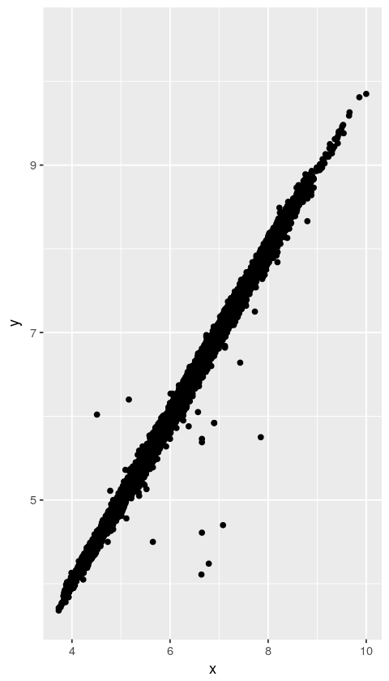

```r
ggplot(data = diamonds_new) +
    geom_point(mapping = aes(x = x, y = y))
```

You can suppress the warning by supplying the value `TRUE` for the argument `na.rm`.

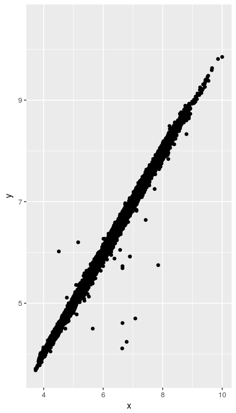

```r
ggplot(data = diamonds_new) +
    geom_point(mapping = aes(x = x, y = y), na.rm = TRUE)
```